# Trade, Coercion, and the EIC

Stephen Weymouth

Dean’s Professor

2026-09-02

## Today: The Rise of the EIC

### Bernstein

China, India, opium, tea, finance, coercion, and changing rules of trade.

### Keay

How English merchants entered Asian trade and later accumulated political power.

Today asks how English merchants built a company with capacities usually associated with states.

## Your IB Voice

Question

Who needed whom more in 1600: the merchant subscribers or the Crown? Test your answer against a counterfactual: What would change if Elizabeth licensed several competing English ventures instead of one monopoly?

**10 minutes** · Individual · Notes permitted · No internet or LLMs

Commit to an explanation before we reconstruct the chapter.

## Hypotheses

Why did one chartered company appeal to both merchants and the Crown?

What changed in the 1590s to make that bargain attractive in 1600?

## How did a nutmeg island become an imperial target?

[figure not shown]

Run was two miles long, had no fresh water, and produced nutmeg.

Its villages answered to no sultan. Councils of *orang kaya* governed each island as a self-governing republic.

Pulo Run had sovereignty of its own to give away.

Nutmeg tree (*Myristica fragrans*) © uforest.org

## The prize was extraordinary

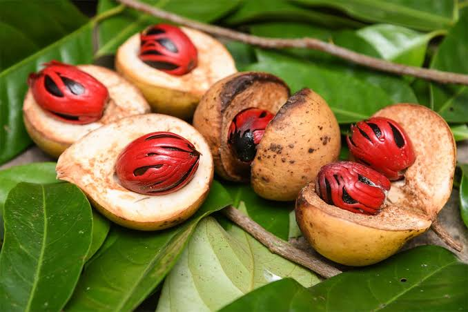

<½ penny → £1.60

Ten pounds of nutmeg  
Banda purchase price → European sale price

One-sixth of a ship’s cargo could pay for the entire voyage.

Nutmeg fruit with mace

# Why a Chartered Company?

## Three forms of trade and sovereign power

### Portugal

**A Crown enterprise**

**Capital:** Crown and merchant contractors

**Returns:** Spice markups, customs, and licence fees to the Crown

**Authority:** Royal fleets, forts, and governors

### The Dutch (VOC)

**A sovereign company**

**Capital:** Private shareholders

**Returns:** Dividends to investors; taxes and charter fees to the Dutch Republic

**Authority:** The VOC could make treaties, build forts, wage war, and govern territory

### The English (EIC)

**A more limited company**

**Capital:** Private voyage subscribers

**Returns:** Profits to investors

**Authority:** Monopoly, factories, diplomacy, and armed ships, but no initial right to rule territory

All three fused commerce and state power. They differed in who paid, who profited, and who ruled.

## Imperialism is broader than colonialism

### Imperialism

Extends effective control across territories and peoples.

It can operate through treaties, finance, monopoly, military force, or delegated company authority.

A local government may formally remain in place.

### Colonialism

Places territory and people under sustained external rule.

Governing authority exercised by crown officials, settlers, or a chartered company.

An empire can dominate without establishing formal colonial rule. Colonialism entails assuming governance authority.

## Around 1600, European trade was one layer of a larger Asian network

**European trade was one small part of a much larger Asian network.**

## Frontier shipping became a question of national power

[figure not shown]

Lancaster’s *Red Dragon*: 600 tons · 38 guns · built for privateering · about 200 men

Isaac Sailmaker, *Two Views of an East Indiaman*, c. 1685 · National Maritime Museum / Wikimedia Commons, public domain

### A frontier capability

Ocean-going hulls combined **cargo capacity, firepower, trained crews, and navigational knowledge**.

### The trigger

Dutch merchants then tried to buy **English ships**.

### The political claim

The petitioners told Elizabeth that the **“national interest”** was at stake.

The Crown needed a way to harness privately assembled strategic capacity.

## The charter bestowed power

A **royal charter** was a sovereign grant creating a corporation and conferring legal privileges.

### What it granted

**Corporate status:** continuity and internal governance

**Monopoly:** exclusive English trade beyond the Cape for 15 years

**Enforcement:** Company licenses; unlicensed trade risked forfeiture

### Who gained

**Subscribers:** English rivals excluded; capital and voyage risk pooled

**The Crown:** privately financed maritime expansion; control over English participation

Merchants received monopoly returns while the Crown gained maritime authority.

# Group Activity

## Where does commercial coordination become imperial power?

Explain the significance of each episode and classify it: **commercial coordination · imperial power · colonial rule**. More than one category may apply.

1. Merchants subscribe capital to Lancaster’s first Company fleet.
2. The 1600 royal charter
3. Lancaster’s dealings with Sultan Ala-uddin at Aceh
4. The seizure of a Portuguese carrack
5. The Bantam factory
6. Country-trade voyages
7. Run and Ai pledge allegiance to the English Crown through Company agents
8. A later charter authorizes the Company to hold, fortify, and settle territory

Pick one episode your group could not agree on. What business problem did it solve? What authority did it exercise? Whose freedom of action did it limit?

**12 minutes** · Groups of 3-4

## The risk undertaken because the returns were large

[figure not shown]

25 of 198

men who rounded the Cape on Lancaster’s 1591 voyage reached England again

On the first Company fleet, **105 of 480** men were dead before it reached the Cape.

Investors accepted these odds because one-sixth of a cargo still returned a profit.

Portrait of Sir James Lancaster · National Maritime Museum / Wikimedia Commons, public domain

## At Aceh, Lancaster negotiated market access

[figure not shown]

### What Ala-uddin granted

A trading house, royal protection, full trading rights, and exemption from customs duties

### What Elizabeth’s letter argued

No nation is self-sufficient, so distant countries should trade with one another.

Any prince who trades with only **one** European nation should expect political subordination to it.

England argued for open trade abroad while chartering a monopoly at home.

Theodor de Bry, Dutch envoys at Sultan Ala-uddin’s court, engraving published 1604 · Wikimedia Commons, public domain

## Armed seizure solved England’s export problem

[figure not shown]

### What Lancaster sailed with

**£20,000** in Spanish silver

**£6,000** in English goods

### What he took by force

Indian textiles that **more than doubled** his trading stock

England had little to sell, so silver and seizure supplied what the market would take.

Portuguese India Armada of 1502, from the *Livro de Lisuarte de Abreu*, c. 1565 · Morgan Library / Wikimedia Commons, public domain

## Bantam was an early analogue of foreign direct investment

[figure not shown]

### Without a factory

Each fleet arrival pushed spice prices up, pushed the price of its own cloth down, and left ships idle waiting for a return cargo.

### With a factory

Resident **factors** bought and sold all year, so prices moved less and cargo was waiting when the fleet arrived.

Local presence changed the terms of every transaction the Company made.

View of Bantam, Java, early seventeenth century · Wikimedia Commons, public domain

## The Company depended on an existing Asian regional network

[figure not shown]

- **Aceh:** diplomacy and political access
- **Priaman:** pepper
- **Bantam:** factory and regional hub
- **Banda:** nutmeg and mace
- **Moluccas:** cloves and subsidiary voyages

The Bantam factory connected large Company ships to smaller Asian vessels carrying goods and market intelligence.

## The EIC did more than its charter mentioned

[figure not shown]

The charter created an English monopoly. EIC added diplomacy, armed seizure, and permanent foreign presence.

## Run turned trade into a territorial commitment

[figure not shown]

- Threatened by the Dutch, Run’s leaders offered allegiance to the English in 1616 (English protection in echagne for nutmeg access).
- The Company’s charter gave it no power to hold territory. The EIC accepted on the king’s behalf.
- Four years of Dutch blockade later, the Company wanted rid of the island (too costly to defend), but King refused

Trade created demands for protection, turning a commercial relationship into a claim to colonial rule.

## The Company met each problem with organization or with force

| Cross-border problem | Company response |
| --- | --- |
| Portuguese and Dutch power restricted access | Charter, royal diplomacy, and armed ships |
| Voyages required capital and risk pooling | Capital subscribed one voyage at a time, then repaid when the ships returned |
| English exports found few Asian buyers | Bullion and country trade supplied tradable goods |
| Fleet arrivals distorted prices and delayed ships | Bantam factors traded year-round and prepared cargo |

## Epilogue: from Spice Race to Colonialism

[figure not shown]

Territorial revenue extraction made permanent military power self-financing.

## The EIC is an ancestor of the modern MNE

### Chartered company

- Permanent factories placed Company agents and assets abroad
- Charter, diplomacy, and armed force supported trade
- Commercial activity generated claims over territory and people

### Modern multinational

- FDI creates a lasting interest and managerial influence abroad
- Market access is governed by host-state law and trade and investment rules
- Firms face political risk but normally lack sovereign authority

The continuity is organization across distance. Modern law more sharply separates corporate authority from sovereign power.

## Reflection: Return to your IB Voice

Why did England organize Asian trade through a monopoly company rather than through competing merchants or direct Crown control?

Revisit your opening answer: explain what the charter solved and what new political problem it created.

## Lessons learned this week

### 1. States carve out markets

The charter and the Canton system decided who could trade. Commerce then acquired armies and territory.

### 2. Open trade has losers, and they fight

Corn Laws Repeal enriched manufacturers and cost landowners. Dutch displacement led to embargo.

### 3. Institutions determine who wins

The same argument loses in a landowners’ Parliament and wins in 1846. A monopoly charter bestows market exclusivity.

### 4. Ideas need political translators

Smith/Ricardo defined the logic of trade. Cobden’s League and a famine shaped politics. Lancaster partied and shared the Queen’s letter.

### 5. Incentives for the illicit

Seized carracks, opium. Norms, law, and weapons imperfectly constrain.

### 6. State and commercial power reinforce each other

Commercial power extends state reach; state power protects commercial advantage.